# Customer Personality Analysis

## Customer Personality Analysis

**Person**  
ID: Customer's unique identifier  
Year_Birth: Customer's birth year  
Education: Customer's education level  
Marital_Status: Customer's marital status  
Income: Customer's yearly household income  
Kidhome: Number of children in customer's household  
Teenhome: Number of teenagers in customer's household  
Dt_Customer: Date of customer's enrollment with the company  
Recency: Number of days since customer's last purchase  
Complain: 1 if the customer complained in the last 2 years, 0 otherwise  
**Products**  
MntWines: Amount spent on wine in last 2 years  
MntFruits: Amount spent on fruits in last 2 years  
MntMeatProducts: Amount spent on meat in last 2 years  
MntFishProducts: Amount spent on fish in last 2 years  
MntSweetProducts: Amount spent on sweets in last 2 years  
MntGoldProds: Amount spent on gold in last 2 years  
**Promotion**  
NumDealsPurchases: Number of purchases made with a discount  
AcceptedCmp1: 1 if customer accepted the offer in the 1st campaign, 0 otherwise  
AcceptedCmp2: 1 if customer accepted the offer in the 2nd campaign, 0 otherwise  
AcceptedCmp3: 1 if customer accepted the offer in the 3rd campaign, 0 otherwise  
AcceptedCmp4: 1 if customer accepted the offer in the 4th campaign, 0 otherwise  
AcceptedCmp5: 1 if customer accepted the offer in the 5th campaign, 0 otherwise  
Response: 1 if customer accepted the offer in the last campaign, 0 otherwise  
**Place**

NumWebPurchases: Number of purchases made through the company’s website  
NumCatalogPurchases: Number of purchases made using a catalogue  
NumStorePurchases: Number of purchases made directly in stores  
NumWebVisitsMonth: Number of visits to company’s website in the last month

[figure not shown]

```python
import pandas as pd
import numpy as np
import seaborn as sns
import matplotlib.pyplot as plt
from matplotlib import colors
%matplotlib inline
```

```python
from sklearn.preprocessing import LabelEncoder
from sklearn.cluster import KMeans
from sklearn.decomposition import PCA
```

```python
import warnings
warnings.filterwarnings('ignore')
```

```python
df = pd.read_csv("https://raw.githubusercontent.com/amankharwal/Website-data/master/marketing_campaign.csv",delimiter=';')
df.head()
```

|  | ID | Year_Birth | Education | Marital_Status | Income | Kidhome | Teenhome | Dt_Customer | Recency | MntWines | ... | NumWebVisitsMonth | AcceptedCmp3 | AcceptedCmp4 | AcceptedCmp5 | AcceptedCmp1 | AcceptedCmp2 | Complain | Z_CostContact | Z_Revenue | Response |
| --- | --- | --- | --- | --- | --- | --- | --- | --- | --- | --- | --- | --- | --- | --- | --- | --- | --- | --- | --- | --- | --- |
| 0 | 5524 | 1957 | Graduation | Single | 58138.0 | 0 | 0 | 2012-09-04 | 58 | 635 | ... | 7 | 0 | 0 | 0 | 0 | 0 | 0 | 3 | 11 | 1 |
| 1 | 2174 | 1954 | Graduation | Single | 46344.0 | 1 | 1 | 2014-03-08 | 38 | 11 | ... | 5 | 0 | 0 | 0 | 0 | 0 | 0 | 3 | 11 | 0 |
| 2 | 4141 | 1965 | Graduation | Together | 71613.0 | 0 | 0 | 2013-08-21 | 26 | 426 | ... | 4 | 0 | 0 | 0 | 0 | 0 | 0 | 3 | 11 | 0 |
| 3 | 6182 | 1984 | Graduation | Together | 26646.0 | 1 | 0 | 2014-02-10 | 26 | 11 | ... | 6 | 0 | 0 | 0 | 0 | 0 | 0 | 3 | 11 | 0 |
| 4 | 5324 | 1981 | PhD | Married | 58293.0 | 1 | 0 | 2014-01-19 | 94 | 173 | ... | 5 | 0 | 0 | 0 | 0 | 0 | 0 | 3 | 11 | 0 |

5 rows × 29 columns

```python
df.shape
```

```
(2240, 29)
```

```python
df.info()
```

```
<class 'pandas.core.frame.DataFrame'>
RangeIndex: 2240 entries, 0 to 2239
Data columns (total 29 columns):
 #   Column               Non-Null Count  Dtype
---  ------               --------------  -----
 0   ID                   2240 non-null   int64
 1   Year_Birth           2240 non-null   int64
 2   Education            2240 non-null   object
 3   Marital_Status       2240 non-null   object
 4   Income               2216 non-null   float64
 5   Kidhome              2240 non-null   int64
 6   Teenhome             2240 non-null   int64
 7   Dt_Customer          2240 non-null   object
 8   Recency              2240 non-null   int64
 9   MntWines             2240 non-null   int64
```

[output cut: 21 more lines]

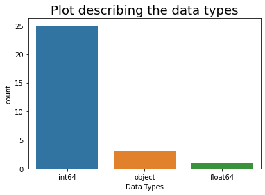

```python
#check type of datatype present
sns.countplot(x=df.dtypes.map(str))
plt.title('Plot describing the data types',fontsize=18)
plt.xlabel('Data Types')
plt.show()
```

```python
#lets check memory usage
memory_usage = df.memory_usage(deep=True) / 1024 ** 2
print('memory usage of features: \n', memory_usage.head(7))
print('memory usage sum: ',memory_usage.sum())
```

```
memory usage of features:
 Index             0.000122
ID                0.017090
Year_Birth        0.017090
Education         0.137827
Marital_Status    0.136875
Income            0.017090
Kidhome           0.017090
dtype: float64
memory usage sum:  0.8622875213623047
```

```python
#reduce memory uasge
def reduce_memory_usage(df, verbose=True):
    numerics = ["int8", "int16", "int32", "int64", "float16", "float32", "float64"]
    start_mem = df.memory_usage().sum() / 1024 ** 2
    for col in df.columns:
        col_type = df[col].dtypes
        if col_type in numerics:
            c_min = df[col].min()
            c_max = df[col].max()
            if str(col_type)[:3] == "int":
                if c_min > np.iinfo(np.int8).min and c_max < np.iinfo(np.int8).max:
                    df[col] = df[col].astype(np.int8)
                elif c_min > np.iinfo(np.int16).min and c_max < np.iinfo(np.int16).max:
                    df[col] = df[col].astype(np.int16)
                elif c_min > np.iinfo(np.int32).min and c_max < np.iinfo(np.int32).max:
                    df[col] = df[col].astype(np.int32)
                elif c_min > np.iinfo(np.int64).min and c_max < np.iinfo(np.int64).max:
                    df[col] = df[col].astype(np.int64)
            else:
                if (
                    c_min > np.finfo(np.float16).min
                    and c_max < np.finfo(np.float16).max
                ):
                    df[col] = df[col].astype(np.float16)
                elif (
                    c_min > np.finfo(np.float32).min
                    and c_max < np.finfo(np.float32).max
                ):
                    df[col] = df[col].astype(np.float32)
                else:
                    df[col] = df[col].astype(np.float64)
    end_mem = df.memory_usage().sum() / 1024 ** 2
    if verbose:
        print(
            "Mem. usage decreased to {:.2f} Mb ({:.1f}% reduction)".format(
                end_mem, 100 * (start_mem - end_mem) / start_mem
            )
        )
    return df

df = reduce_memory_usage(df, verbose=True)
```

```
Mem. usage decreased to 0.13 Mb (73.7% reduction)
```

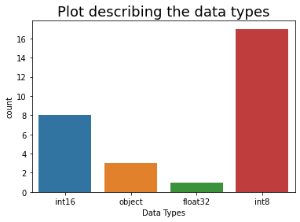

```python
#check type of datatype present
sns.countplot(x=df.dtypes.map(str))
plt.title('Plot describing the data types',fontsize=18)
plt.xlabel('Data Types')
plt.show()
```

```python
print(df.isna().sum())
```

```
ID                      0
Year_Birth              0
Education               0
Marital_Status          0
Income                 24
Kidhome                 0
Teenhome                0
Dt_Customer             0
Recency                 0
MntWines                0
MntFruits               0
MntMeatProducts         0
MntFishProducts         0
MntSweetProducts        0
MntGoldProds            0
NumDealsPurchases       0
NumWebPurchases         0
NumCatalogPurchases     0
NumStorePurchases       0
NumWebVisitsMonth       0
AcceptedCmp3            0
AcceptedCmp4            0
AcceptedCmp5            0
AcceptedCmp1            0
AcceptedCmp2            0
Complain                0
Z_CostContact           0
Z_Revenue               0
Response                0
dtype: int64
```

```python
#calculate precentage of missing values
def missing_data(df):
    total = df.isnull().sum().sort_values(ascending = False)
    Percentage = (df.isnull().sum()/df.count()*100).sort_values(ascending = False)
    return pd.concat([total, Percentage], axis=1, keys=['Total', 'Percentage'])
missing_data(df).style.background_gradient(cmap='Blues')
```

|  | Total | Percentage |
| --- | --- | --- |
| Income | 24 | 1.083032 |
| ID | 0 | 0.000000 |
| NumDealsPurchases | 0 | 0.000000 |
| Z_Revenue | 0 | 0.000000 |
| Z_CostContact | 0 | 0.000000 |
| Complain | 0 | 0.000000 |
| AcceptedCmp2 | 0 | 0.000000 |
| AcceptedCmp1 | 0 | 0.000000 |
| AcceptedCmp5 | 0 | 0.000000 |
| AcceptedCmp4 | 0 | 0.000000 |
| AcceptedCmp3 | 0 | 0.000000 |
| NumWebVisitsMonth | 0 | 0.000000 |
| NumStorePurchases | 0 | 0.000000 |
| NumCatalogPurchases | 0 | 0.000000 |
| NumWebPurchases | 0 | 0.000000 |
| MntGoldProds | 0 | 0.000000 |
| Year_Birth | 0 | 0.000000 |
| MntSweetProducts | 0 | 0.000000 |
| MntFishProducts | 0 | 0.000000 |
| MntMeatProducts | 0 | 0.000000 |
| MntFruits | 0 | 0.000000 |
| MntWines | 0 | 0.000000 |
| Recency | 0 | 0.000000 |
| Dt_Customer | 0 | 0.000000 |
| Teenhome | 0 | 0.000000 |
| Kidhome | 0 | 0.000000 |
| Marital_Status | 0 | 0.000000 |
| Education | 0 | 0.000000 |
| Response | 0 | 0.000000 |

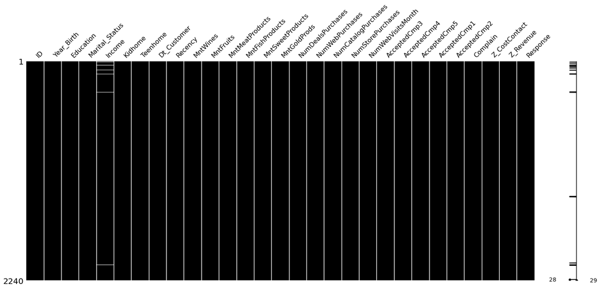

```python
#exploratory visualization of missing data
import missingno as msno
msno.matrix(df,color = (0,0,0))
plt.show()
```

#### Data Cleaning

```python
#going to descripe our dataset to get better understanding
df.describe()
```

|  | ID | Year_Birth | Income | Kidhome | Teenhome | Recency | MntWines | MntFruits | MntMeatProducts | MntFishProducts | ... | NumWebVisitsMonth | AcceptedCmp3 | AcceptedCmp4 | AcceptedCmp5 | AcceptedCmp1 | AcceptedCmp2 | Complain | Z_CostContact | Z_Revenue | Response |
| --- | --- | --- | --- | --- | --- | --- | --- | --- | --- | --- | --- | --- | --- | --- | --- | --- | --- | --- | --- | --- | --- |
| count | 2240.000000 | 2240.000000 | 2216.000000 | 2240.000000 | 2240.000000 | 2240.000000 | 2240.000000 | 2240.000000 | 2240.000000 | 2240.000000 | ... | 2240.000000 | 2240.000000 | 2240.000000 | 2240.000000 | 2240.000000 | 2240.000000 | 2240.000000 | 2240.0 | 2240.0 | 2240.000000 |
| mean | 5592.159821 | 1968.805804 | 52247.281250 | 0.444196 | 0.506250 | 49.109375 | 303.935714 | 26.302232 | 166.950000 | 37.525446 | ... | 5.316518 | 0.072768 | 0.074554 | 0.072768 | 0.064286 | 0.013393 | 0.009375 | 3.0 | 11.0 | 0.149107 |
| std | 3246.662198 | 11.984069 | 25173.074219 | 0.538398 | 0.544538 | 28.962453 | 336.597393 | 39.773434 | 225.715373 | 54.628979 | ... | 2.426645 | 0.259813 | 0.262728 | 0.259813 | 0.245316 | 0.114976 | 0.096391 | 0.0 | 0.0 | 0.356274 |
| min | 0.000000 | 1893.000000 | 1730.000000 | 0.000000 | 0.000000 | 0.000000 | 0.000000 | 0.000000 | 0.000000 | 0.000000 | ... | 0.000000 | 0.000000 | 0.000000 | 0.000000 | 0.000000 | 0.000000 | 0.000000 | 3.0 | 11.0 | 0.000000 |
| 25% | 2828.250000 | 1959.000000 | 35303.000000 | 0.000000 | 0.000000 | 24.000000 | 23.750000 | 1.000000 | 16.000000 | 3.000000 | ... | 3.000000 | 0.000000 | 0.000000 | 0.000000 | 0.000000 | 0.000000 | 0.000000 | 3.0 | 11.0 | 0.000000 |
| 50% | 5458.500000 | 1970.000000 | 51381.500000 | 0.000000 | 0.000000 | 49.000000 | 173.500000 | 8.000000 | 67.000000 | 12.000000 | ... | 6.000000 | 0.000000 | 0.000000 | 0.000000 | 0.000000 | 0.000000 | 0.000000 | 3.0 | 11.0 | 0.000000 |
| 75% | 8427.750000 | 1977.000000 | 68522.000000 | 1.000000 | 1.000000 | 74.000000 | 504.250000 | 33.000000 | 232.000000 | 50.000000 | ... | 7.000000 | 0.000000 | 0.000000 | 0.000000 | 0.000000 | 0.000000 | 0.000000 | 3.0 | 11.0 | 0.000000 |
| max | 11191.000000 | 1996.000000 | 666666.000000 | 2.000000 | 2.000000 | 99.000000 | 1493.000000 | 199.000000 | 1725.000000 | 259.000000 | ... | 20.000000 | 1.000000 | 1.000000 | 1.000000 | 1.000000 | 1.000000 | 1.000000 | 3.0 | 11.0 | 1.000000 |

8 rows × 26 columns

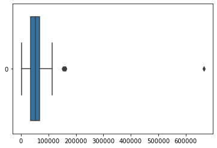

```python
#checking outlier present or not
sns.boxplot(data=df.Income,orient='h')
plt.show()
```

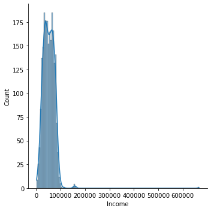

```python
#checking distribution of data
sns.displot(df.Income,kde=True)
plt.show()
```

```python
#will drop this because it can be a outlier , and if we see histogram it is right skewed
df[df.Income > 200000]
```

|  | ID | Year_Birth | Education | Marital_Status | Income | Kidhome | Teenhome | Dt_Customer | Recency | MntWines | ... | NumWebVisitsMonth | AcceptedCmp3 | AcceptedCmp4 | AcceptedCmp5 | AcceptedCmp1 | AcceptedCmp2 | Complain | Z_CostContact | Z_Revenue | Response |
| --- | --- | --- | --- | --- | --- | --- | --- | --- | --- | --- | --- | --- | --- | --- | --- | --- | --- | --- | --- | --- | --- |
| 2233 | 9432 | 1977 | Graduation | Together | 666666.0 | 1 | 0 | 2013-06-02 | 23 | 9 | ... | 6 | 0 | 0 | 0 | 0 | 0 | 0 | 3 | 11 | 0 |

1 rows × 29 columns

```python
df.drop(df[df.Income > 200000].index,inplace=True,axis=0)
```

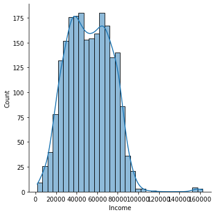

```python
#now our data is normally distributed
sns.displot(df.Income,kde=True)
plt.show()
```

```python
df['Income'].fillna(df['Income'].median(),inplace=True)
```

```python
df[df.Income.isna()]
```

|  | ID | Year_Birth | Education | Marital_Status | Income | Kidhome | Teenhome | Dt_Customer | Recency | MntWines | ... | NumWebVisitsMonth | AcceptedCmp3 | AcceptedCmp4 | AcceptedCmp5 | AcceptedCmp1 | AcceptedCmp2 | Complain | Z_CostContact | Z_Revenue | Response |
| --- | --- | --- | --- | --- | --- | --- | --- | --- | --- | --- | --- | --- | --- | --- | --- | --- | --- | --- | --- | --- | --- |

0 rows × 29 columns

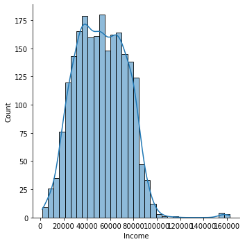

```python
#Income data is normally distributed
sns.displot(df.Income,kde=True)
plt.show()
```

```python
df.nunique()
```

```
ID                     2239
Year_Birth               59
Education                 5
Marital_Status            8
Income                 1973
Kidhome                   3
Teenhome                  3
Dt_Customer             663
Recency                 100
MntWines                776
MntFruits               158
MntMeatProducts         558
MntFishProducts         182
MntSweetProducts        177
MntGoldProds            213
NumDealsPurchases        15
NumWebPurchases          15
NumCatalogPurchases      14
NumStorePurchases        14
NumWebVisitsMonth        16
AcceptedCmp3              2
AcceptedCmp4              2
AcceptedCmp5              2
AcceptedCmp1              2
AcceptedCmp2              2
Complain                  2
Z_CostContact             1
Z_Revenue                 1
Response                  2
dtype: int64
```

**Note : From above its clearly visible ,Z_CostContact and Z_Revenue have only single value or same value . Hence this column will not be helpful for ML models . We can drop it**

```python
#dropping unwanted columns
df.drop(columns=['Z_CostContact','Z_Revenue'],inplace=True)
```

**Now we will be exploring the unique values in the categorical features to get a clear idea of the data.**

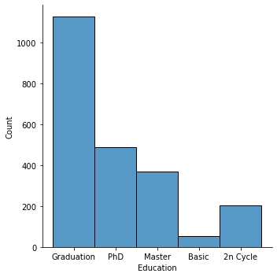

```python
#Analysis on Education column
sns.displot(df.Education)
plt.show()
```

```python
#creating 2 groups PG and UG
df['Education'] = df['Education'].replace(['PhD','2n Cycle','Graduation', 'Master'],'Post Graduate')
df['Education'] = df['Education'].replace(['Basic'], 'Under Graduate')
```

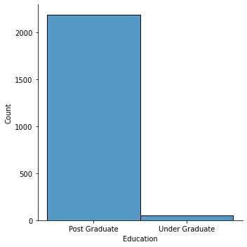

```python
sns.displot(df.Education)
plt.show()
```

```python
##Analysis on Marital column
df['Marital_Status'].value_counts()
```

```
Married     864
Together    579
Single      480
Divorced    232
Widow        77
Alone         3
Absurd        2
YOLO          2
Name: Marital_Status, dtype: int64
```

**will create two groups , Single and Relationship**

```python
df['Marital_Status'] = df['Marital_Status'].replace(['Married', 'Together'],'Relationship')
df['Marital_Status'] = df['Marital_Status'].replace(['Divorced', 'Widow', 'Alone', 'YOLO', 'Absurd'],'Single')
```

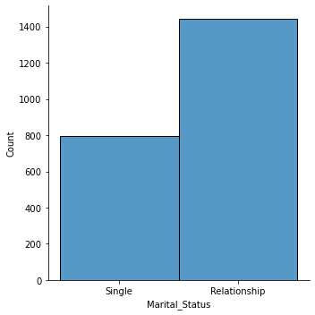

```python
sns.displot(df.Marital_Status)
plt.show()
```

```python
#Analysis on Teenhome and Kidhome column
print('Teen home \n',df.Teenhome.value_counts(),'\n')
print('Kid home \n',df.Kidhome.value_counts())
```

```
Teen home
 0    1157
1    1030
2      52
Name: Teenhome, dtype: int64

Kid home
 0    1293
1     898
2      48
Name: Kidhome, dtype: int64
```

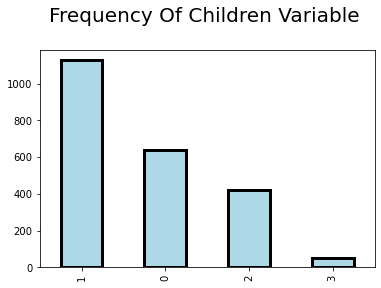

```python
#combining Teenhome and Kidhome column to a single column Children, hence reducing number of features
df['Children'] = df['Teenhome'] + df['Kidhome']

#VISUALIZING THE "No of children in house"
df['Children'].value_counts().plot(kind='bar',color = 'lightBlue',edgecolor = "black",linewidth = 3)
plt.title("Frequency Of Children Variable \n",fontsize=20)
plt.figure(figsize=(8,8))
plt.show()
```

```python
df["Family_Size"] = df["Marital_Status"].replace({"Single": 1, "Relationship":2})+ df["Children"]
```

```python
# Combining different dataframe into a single column to reduce the number of dimension
df['Expenses'] = df['MntWines'] + df['MntFruits'] + df['MntMeatProducts'] + df['MntFishProducts'] + df['MntSweetProducts'] + df['MntGoldProds']
```

```python
#combing all types camp to one
df['TotalAcceptedCmp'] = df['AcceptedCmp1'] + df['AcceptedCmp2'] + df['AcceptedCmp3'] + df['AcceptedCmp4'] + df['AcceptedCmp5']
```

```python
#method of purchase
df['NumTotalPurchases'] = df['NumWebPurchases'] + df['NumCatalogPurchases'] + df['NumStorePurchases']
```

```python
#Removing columns which are not needed for RFM
col_del = ["ID","AcceptedCmp1" , "AcceptedCmp2", "AcceptedCmp3" , "AcceptedCmp4","AcceptedCmp5","NumWebVisitsMonth", "NumWebPurchases","NumCatalogPurchases","NumStorePurchases" , "Kidhome", "Teenhome","MntWines", "MntFruits", "MntMeatProducts", "MntFishProducts", "MntSweetProducts", "MntGoldProds"]
df=df.drop(columns=col_del,axis=1)
df.head()
```

|  | Year_Birth | Education | Marital_Status | Income | Dt_Customer | Recency | NumDealsPurchases | Complain | Response | Children | Family_Size | Expenses | TotalAcceptedCmp | NumTotalPurchases |
| --- | --- | --- | --- | --- | --- | --- | --- | --- | --- | --- | --- | --- | --- | --- |
| 0 | 1957 | Post Graduate | Single | 58138.0 | 2012-09-04 | 58 | 3 | 0 | 1 | 0 | 1 | 1617 | 0 | 22 |
| 1 | 1954 | Post Graduate | Single | 46344.0 | 2014-03-08 | 38 | 2 | 0 | 0 | 2 | 3 | 27 | 0 | 4 |
| 2 | 1965 | Post Graduate | Relationship | 71613.0 | 2013-08-21 | 26 | 1 | 0 | 0 | 0 | 2 | 776 | 0 | 20 |
| 3 | 1984 | Post Graduate | Relationship | 26646.0 | 2014-02-10 | 26 | 2 | 0 | 0 | 1 | 3 | 53 | 0 | 6 |
| 4 | 1981 | Post Graduate | Relationship | 58293.0 | 2014-01-19 | 94 | 5 | 0 | 0 | 1 | 3 | 422 | 0 | 14 |

**Lets see our oldest and newest customer**

```python
df['Dt_Customer'] = pd.to_datetime(df.Dt_Customer)
```

```python
#checking the record of customer
print('Oldest Customer : ',min(df['Dt_Customer']))
print('Newest Customer : ',max(df['Dt_Customer']))
```

```
Oldest Customer :  2012-07-30 00:00:00
Newest Customer :  2014-06-29 00:00:00
```

```
Let's create a variable named `Customer For`. Customers are registered here
According to the newest customer, let's observe the status of other customers in days
We will be using our variable later in the visualization
```

```python
days = []
d1 = max(df['Dt_Customer']) #taking it to be the newest customer
for i in df['Dt_Customer']:
    delta = d1 - i
    days.append(delta.days)
df["Customer_For"] = days
```

```python
#calculating Age
df['Age'] = (pd.Timestamp('now').year) - df['Year_Birth']
```

```python
df=df.drop(columns=["Dt_Customer", "Year_Birth", "Complain","Response"],axis=1)
```

```python
df.head(3)
```

|  | Education | Marital_Status | Income | Recency | NumDealsPurchases | Children | Family_Size | Expenses | TotalAcceptedCmp | NumTotalPurchases | Customer_For | Age |
| --- | --- | --- | --- | --- | --- | --- | --- | --- | --- | --- | --- | --- |
| 0 | Post Graduate | Single | 58138.0 | 58 | 3 | 0 | 1 | 1617 | 0 | 22 | 663 | 66 |
| 1 | Post Graduate | Single | 46344.0 | 38 | 2 | 2 | 3 | 27 | 0 | 4 | 113 | 69 |
| 2 | Post Graduate | Relationship | 71613.0 | 26 | 1 | 0 | 2 | 776 | 0 | 20 | 312 | 58 |

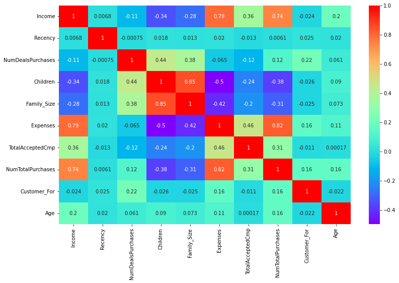

```python
#Visually explore it using a heat map.
plt.subplots(figsize=(13,8))
sns.heatmap(df.corr(),annot=True,cmap='rainbow')
plt.show()
```

**Highly correlated columns**

1. Expenses correlated NumTotalPurchases : 82%
2. Expenses correlated Income : 79%
3. Income correlated NumTotalPurchases : 74%

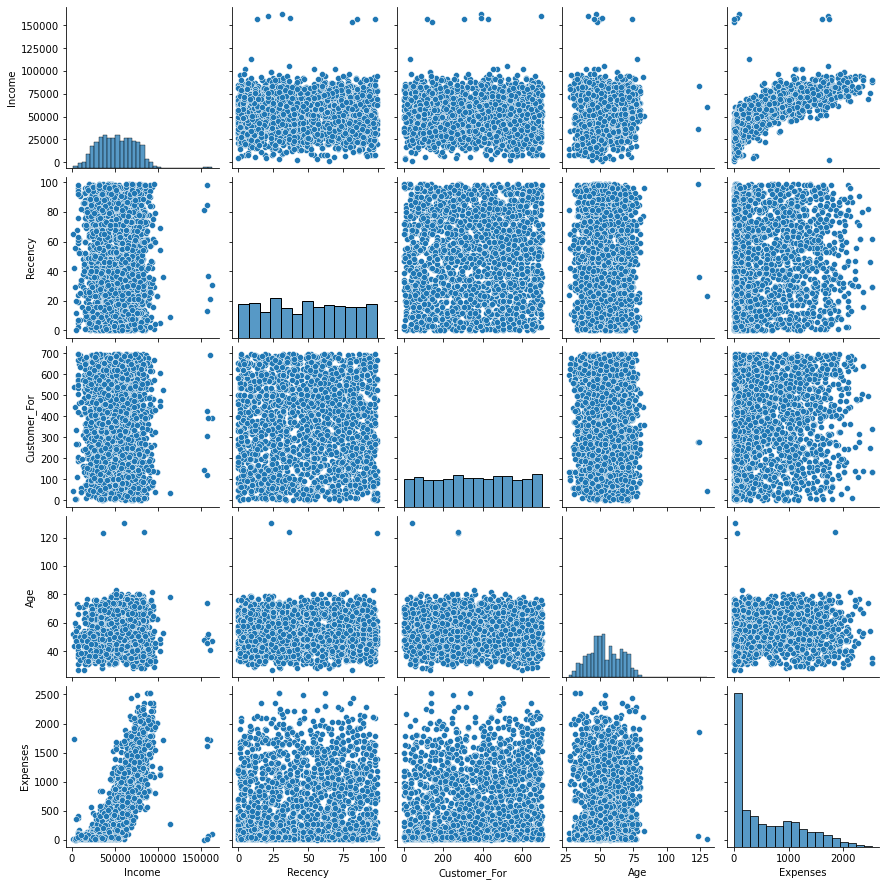

```python
sns.pairplot(df[[ "Income", "Recency", "Customer_For", "Age", "Expenses"]])
```

```python
#Age is exceeding more than 100, becasue this is older dataset. will add cap
df = df[(df["Age"]<90)]
```

**Performing Preprocessing**

In this section, I will be preprocessing the data to perform clustering operations.

The following steps are applied to preprocess the data:

```
Label encoding the categorical features
Scaling the features using the standard scaler
Creating a subset dataframe for dimensionality reduction
```

```python
#list of categorical feature
s = (df.dtypes == object)
cat_list = list(s[s].index)
print('Categorical Features : ',cat_list)
```

```
Categorical Features :  ['Education', 'Marital_Status']
```

```python
lbe = LabelEncoder()

for i in cat_list:
    df[i] = df[[i]].apply(lbe.fit_transform)
```

```python
df
```

|  | Education | Marital_Status | Income | Recency | NumDealsPurchases | Children | Family_Size | Expenses | TotalAcceptedCmp | NumTotalPurchases | Customer_For | Age |
| --- | --- | --- | --- | --- | --- | --- | --- | --- | --- | --- | --- | --- |
| 0 | 0 | 1 | 58138.0 | 58 | 3 | 0 | 1 | 1617 | 0 | 22 | 663 | 66 |
| 1 | 0 | 1 | 46344.0 | 38 | 2 | 2 | 3 | 27 | 0 | 4 | 113 | 69 |
| 2 | 0 | 0 | 71613.0 | 26 | 1 | 0 | 2 | 776 | 0 | 20 | 312 | 58 |
| 3 | 0 | 0 | 26646.0 | 26 | 2 | 1 | 3 | 53 | 0 | 6 | 139 | 39 |
| 4 | 0 | 0 | 58293.0 | 94 | 5 | 1 | 3 | 422 | 0 | 14 | 161 | 42 |
| ... | ... | ... | ... | ... | ... | ... | ... | ... | ... | ... | ... | ... |
| 2235 | 0 | 0 | 61223.0 | 46 | 2 | 1 | 3 | 1341 | 0 | 16 | 381 | 56 |
| 2236 | 0 | 0 | 64014.0 | 56 | 7 | 3 | 5 | 444 | 1 | 15 | 19 | 77 |
| 2237 | 0 | 1 | 56981.0 | 91 | 1 | 0 | 1 | 1241 | 1 | 18 | 155 | 42 |
| 2238 | 0 | 0 | 69245.0 | 8 | 2 | 1 | 3 | 843 | 0 | 21 | 156 | 67 |
| 2239 | 0 | 0 | 52869.0 | 40 | 3 | 2 | 4 | 172 | 0 | 8 | 622 | 69 |

2236 rows × 12 columns

All Features are numerical

```python
import copy
ds = copy.deepcopy(df)
```

```python
#standaradizing the dataset
from sklearn.preprocessing import StandardScaler
ss = StandardScaler()
ss.fit(ds)
standard_ds = pd.DataFrame(ss.transform(ds),columns = ds.columns)
```

Data have been standardized

```python
#Applying PCA
pca = PCA(n_components=3,random_state=0)
pca.fit(standard_ds)
PCA_ds = pd.DataFrame(pca.transform(standard_ds),columns=(["col1","col2", "col3"]))
PCA_ds.describe().T
```

|  | count | mean | std | min | 25% | 50% | 75% | max |
| --- | --- | --- | --- | --- | --- | --- | --- | --- |
| col1 | 2236.0 | -3.574958e-17 | 1.877545 | -4.457863 | -1.565786 | -0.376598 | 1.405686 | 5.456568 |
| col2 | 2236.0 | 3.733845e-17 | 1.370175 | -4.907341 | -0.860012 | -0.022668 | 0.872490 | 5.346096 |
| col3 | 2236.0 | 3.043679e-17 | 1.111882 | -2.738775 | -0.826671 | -0.066484 | 0.717145 | 5.149297 |

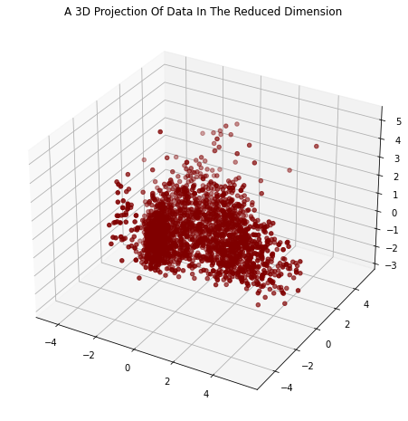

```python
#A 3D Projection Of Data In The Reduced Dimension
x =PCA_ds["col1"]
y =PCA_ds["col2"]
z =PCA_ds["col3"]
#To plot
fig = plt.figure(figsize=(10,8))
ax = fig.add_subplot(111, projection="3d")
ax.scatter(x,y,z, c="maroon", marker="o" )
ax.set_title("A 3D Projection Of Data In The Reduced Dimension")
plt.show()
```

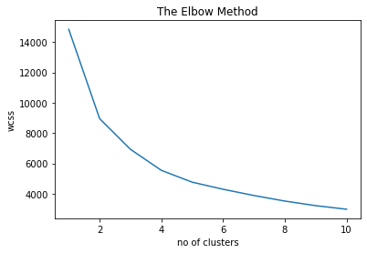

```python
#plotting Elbow method , to decide number of clusters to use
wcss = []

for i in range(1,11):
    kmeans = KMeans(n_clusters= i, random_state=0)
    kmeans.fit(PCA_ds)
    wcss.append(kmeans.inertia_)

plt.plot(range(1,11), wcss)
plt.title('The Elbow Method')
plt.xlabel('no of clusters')
plt.ylabel('wcss')
plt.show()
```

```python
final_kmeans = KMeans(n_clusters= 4, random_state=0)
kmeans_clusters = final_kmeans.fit_predict(PCA_ds)
PCA_ds['Clusters'] = kmeans_clusters
#adding clusters to original dataframe
df['Clusters'] = kmeans_clusters
```

**Let's Examine the Clusters**

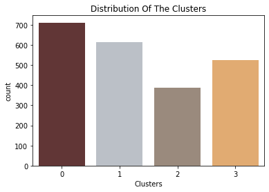

```python
pal = ["#682F2F","#B9C0C9", "#9F8A78","#F3AB60"]
pl = sns.countplot(x=df["Clusters"], palette= pal)
pl.set_title("Distribution Of The Clusters")
plt.show()
```

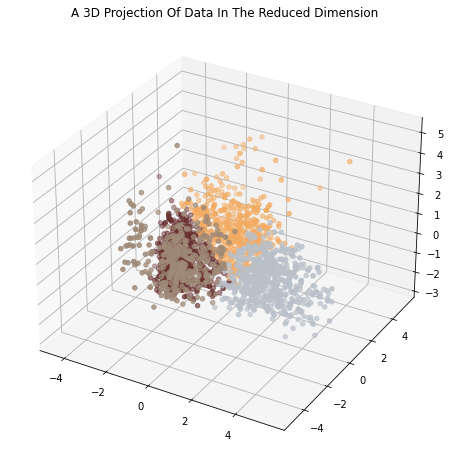

```python
#A 3D Projection Of Data In The Reduced Dimension
x =PCA_ds["col1"]
y =PCA_ds["col2"]
z =PCA_ds["col3"]
#To plot
fig = plt.figure(figsize=(10,8))
ax = fig.add_subplot(111, projection="3d")
ax.scatter(x,y,z, c=PCA_ds['Clusters'], marker="o" ,cmap = colors.ListedColormap(pal))
ax.set_title("A 3D Projection Of Data In The Reduced Dimension")
plt.show()
```

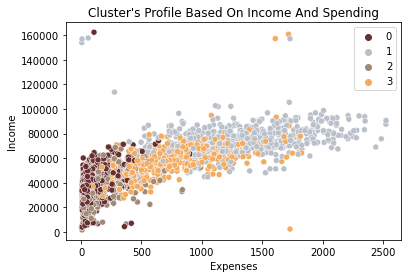

```python
pl = sns.scatterplot(data = df,x=df["Expenses"], y=df["Income"],hue=df["Clusters"], palette= pal)
pl.set_title("Cluster's Profile Based On Income And Spending")
plt.legend()
plt.show()
```

Income vs spending plot shows the clusters pattern

```
group 0: low spending & average income
group 1: high spending & high income
group 2: low spending & low income
group 3: average spending & high income
```

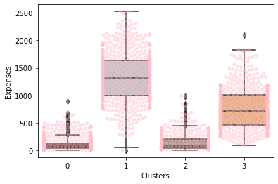

```python
#Now let us see the detailed observation of clusters , on various product spent
plt.figure()
pl=sns.swarmplot(x=df["Clusters"], y=df["Expenses"], color= "pink", alpha=0.5 )
pl=sns.boxplot(x=df["Clusters"], y=df["Expenses"], palette=pal)
plt.show()
```

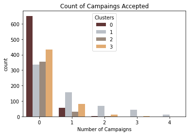

```python
#lets check how campaings have worked out
sns.countplot(x=df['TotalAcceptedCmp'],hue=df['Clusters'],palette=pal)
plt.title('Count of Campaings Accepted')
plt.xlabel('Number of Campaigns')
plt.show()
```

we can see that campaings haven't worked that great, there are not much people took interest . we need to do better in out campaings to boost sales

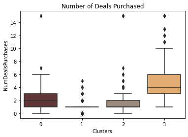

```python
#lets check , Number of purchases made with a discount
plt.figure()
pl=sns.boxplot(y=df["NumDealsPurchases"],x=df["Clusters"], palette= pal)
pl.set_title("Number of Deals Purchased")
plt.show()
```

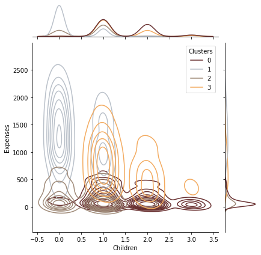

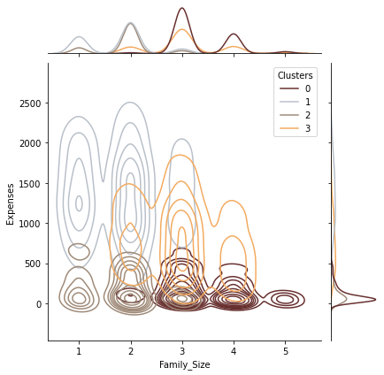

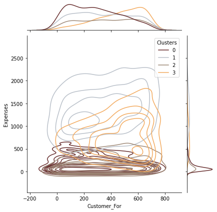

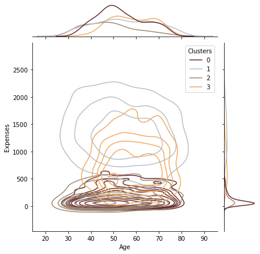

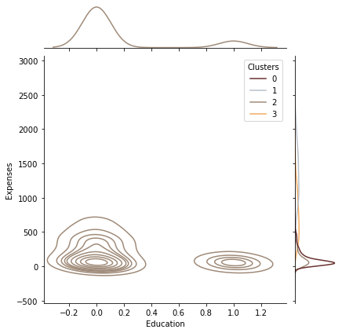

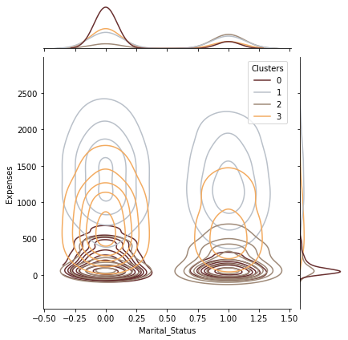

```python
Personal = [ "Children","Family_Size","Customer_For", "Age", "Education","Marital_Status"]

for i in Personal:
    plt.figure()
    sns.jointplot(x=df[i], y=df["Expenses"], hue =df["Clusters"], kind="kde", palette=pal)
    plt.show()
```